# Report: Selection of Pro-Productive Sugarcane Families via Machine Learning

Final Exam_EST792

Blessing, Inácio, Lucas e Rodrigo

2026 June

# 1 Introduction and Objectives

This reported develops predictive models to estimate the yield of 60 sugarcane families, utilizing data from an experiment conducted under a Randomized Complete Block Design (RCBD) in Oratórios, MG. To achieve this, multiple Machine Learning approaches were evaluated and compared from both classification and regression perspectives

```r
knitr::opts_chunk$set(echo = TRUE, warning = FALSE, message = FALSE, fig.align = 'center')
library(tidyverse)
library(readxl)
library(corrplot)
library(car)
library(leaps)
library(caret)
library(class)
```

#Data Import and Pre-Processing

```r
# Data Import
dd3 <- read_excel("dd3.xlsx")

# Filtering and renaming variables
dados <- dd3 %>%
  dplyr::select(
    Family = Familia,     #the sugarcane family under evaluation;
    SN     = NC,        #  average stalk number, per plot;
    TSH    = TCH.x,     # tons of stalks per hectare, per plot;
    SD     = DIAMETRO,  # average stalk diameter, per plot;
    SH     = ALTURA,    # average stalk height, per plot;
    R      = Red,       # the mean reflectance value of the visible band Red, per plot;
    G      = Green,     # the mean reflectance value of the visible band Green, per plot;
    B      = Blue,      # the mean reflectance value of the visible band Blue, per plot;
    VARI   = VARI,      #  derived vegetation index from the visible bands, per plot;
    GLI    = GLI,       # Green Leaf Index
    NGRDI  = NGRDI      # Normalized Green Red Difference Index
  )
```

Exploratory analysis - Correlation Matrix

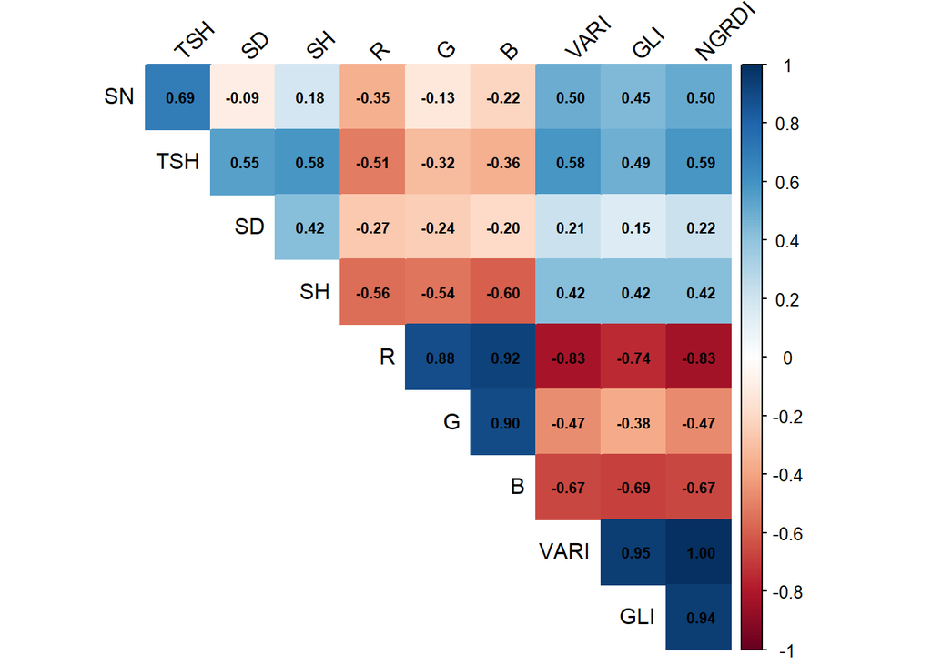

```r
matriz_cor <- cor(dados[, -1])

corrplot(matriz_cor,
         method = "color",
         type = "upper",
         addCoef.col = "black",
         tl.col = "black",
         tl.srt = 45,
         number.cex = 0.7,
         diag = FALSE)
```

> **Important Notes:** > > * VARI has a high correlation with GLI and NCRDI.

> - SN has a medium correlation with TSH.
> - R shows a correlation with all variables that are not “physical”.
> - GLI has a strong correlation with NCRDI.

> **Attention:** For the selection of variables that will be maintained or removed from the next steps, it is essential to take these relationships into consideration.

# 2 Classification Problem

## 2.1 Preparation for classification models

To adjust the logistic regression model, we need a categorical (binary) response variable. Here, we create classes based on the mean of the TSH variable (Tons of stalks per hectare):

- **Class 1 (1):** TSH $\geq$ Average (High productivity)
- **Class 2 (0):** TSH $<$ Average (Low productivity)

```r
# Creating the indicator variable for productivity classes.
dados$TSH_class <- ifelse(dados$TSH >= mean(dados$TSH), "class1", "class2")

# Converting to a factor and defining the reference class
# Note: The first class provided ("class2") receives the value 0 (Reference)
# The second class ("class1") receives the value 1 (Event of interest)
dados$TSH_class <- factor(dados$TSH_class, levels = c("class2", "class1"))

# Checking the updated variables in the dataset
names(dados)
```

```
##  [1] "Family"    "SN"        "TSH"       "SD"        "SH"        "R"
##  [7] "G"         "B"         "VARI"      "GLI"       "NGRDI"     "TSH_class"
```

## 2.2 Data Splitting (Training and Testing)

To evaluate the model’s generalization ability, the dataset was split. Half of the observations were randomly selected for training and the remainder for testing.

```r
# Defining seed to ensure reproducibility (equal results every time)
set.seed(1234)

# Randomly selecting the row indices to create the training set (50% of the data)
l_treino <- sample(1:nrow(dados), size = 0.5 * nrow(dados))

# Applying the drawn indices to separate the data
treino <- dados[l_treino, ]
Teste <- dados[-l_treino, ] #
```

## 2.3 Logistic Model

In this first step, we adjust the logistic regression model using all available variables to predict productivity.

```r
# Model adjustment with all covariates
l_glm.fit <- glm(TSH_class ~ SN + SD + SH + R + G + B + VARI + GLI + NGRDI,
                 data = treino,
                 family = binomial)

# Displaying the coefficients and summary of the model.
summary(l_glm.fit)$coef
```

```
##                 Estimate Std. Error       z value  Pr(>|z|)
## (Intercept)  -1438.79223    6226494 -2.310758e-04 0.9998156
## SN              60.91696     171724  3.547375e-04 0.9997170
## SD              32.52803     238144  1.365898e-04 0.9998910
## SH              78.59020    1839243  4.272964e-05 0.9999659
## R               15.18151    1381192  1.099159e-05 0.9999912
## G              125.74249    1369032  9.184774e-05 0.9999267
## B             -140.43852    2054432 -6.835881e-05 0.9999455
## VARI        -22899.64445  294447155 -7.777166e-05 0.9999379
## GLI         -44624.16922  677258070 -6.588946e-05 0.9999474
## NGRDI        69101.00676 1045031433  6.612338e-05 0.9999472
```

With the inclusion of all variables, the model showed complete separation between Class 1 and Class 2. A perfect fit to the training data (overfitting) occurred, which absurdly inflates the standard errors and prevents the coefficients from being reliable for prediction.

### 2.3.1 Evaluation of the Logistic Model

To verify the model’s actual performance, we generated predictions using the test set. The model returns the **probability** of each observation belonging to Class 1.

We adopted a threshold of 0.5: if the probability is greater than 50%, we classify it as “class 1”.

```r
# Generating probabilities in the test set
prob_teste <- predict(l_glm.fit, newdata = Teste, type = "response")

# Assigning the class based on the probability obtained
pred_teste <- ifelse(prob_teste > 0.5, "class1", "class2")

# Confusion Matrix
table(Predicted = pred_teste, True = Teste$TSH_class)
```

```
##          True
## Predicted class2 class1
##    class1      4     12
##    class2     13      1
```

```r
# Calculating the Test Error Rate
erro_teste_l_glm <- mean(pred_teste != Teste$TSH_class)
cat("Error Rate of Logistic Regression on the Test Set:", erro_teste_l_glm * 100, "%\n")
```

```
## Error Rate of Logistic Regression on the Test Set: 16.66667 %
```

Evaluating the Result: The error rate in the test was low (16.66%). However, since the sample is small and the training model suffered from perfect separation (overfitting), this metric may be misleading.

## 2.4 Linear Discriminant Analysis (LDA)

As an alternative to Logistic Regression, we fitted a Linear Discriminant Analysis (LDA) model, which tends to be more stable when the classes are well separable or when there is a strong correlation between the variables.

```r
library(MASS)
# Adjusting the LDA model with the training data
lda.fit <- lda(TSH_class ~ SN + SD + SH + R + G + B + VARI + GLI + NGRDI,
               data = treino)

# Viewing model information
lda.fit
```

```
## Call:
## lda(TSH_class ~ SN + SD + SH + R + G + B + VARI + GLI + NGRDI,
##     data = treino)
##
## Prior probabilities of groups:
##    class2    class1
## 0.4333333 0.5666667
##
## Group means:
##              SN       SD       SH        R        G        B        VARI
## class2 6.425940 23.70295 2.051285 90.27834 86.06916 84.25785 -0.04139750
## class1 7.534298 24.68713 2.258829 86.59452 85.39781 82.21276 -0.01119092
##                 GLI        NGRDI
## class2 -0.005579165 -0.021728534
## class1  0.006233092 -0.006028597
##
## Coefficients of linear discriminants:
##                 LD1
## SN        1.5351835
## SD        0.8479873
## SH        3.0418829
## R         0.7651063
## G         5.0026847
## B        -5.8951588
## VARI   -134.2597690
## GLI   -1873.0538155
## NGRDI  1325.3232284
```

### 2.4.1 LDA Model Evaluation (Test Data)

As we did with the logistic model, we evaluated the LDA’s performance on data it hasn’t yet “seen”.

```r
#the MASS package already applies the automatic 50% threshold for classification.
# Performing the prediction on the test set
lda.pred <- predict(lda.fit, newdata = Teste)

# Extracting the vector with the predicted classes
lda.class <- lda.pred$class

# Confusion Matrix (LDA)
table(Predicted = lda.class, Real = Teste$TSH_class)
```

```
##          Real
## Predicted class2 class1
##    class2     12      2
##    class1      5     11
```

```r
# Calculating the LDA Test Error Rate
erro_teste_lda <- mean(lda.class != Teste$TSH_class)
cat("LDA Error Rate in Testing:", erro_teste_lda * 100, "%\n")
```

```
## LDA Error Rate in Testing: 23.33333 %
```

Important Conclusion (Logistic vs. LDA): The error rate of LDA (23.33%) was slightly higher than that of Logistic Regression (16.66%). However, LDA stands out as a more robust and reliable option in this scenario, as it does not suffer from the problem of total separation (extreme overfitting) that invalidated the coefficients of the initial logistic model.

## 2.5 K-Nearest Neighbors (KNN)

Unlike the previous models, KNN is based on the distance between observations. Because of this, **standardizing the variables** is a mandatory step so that measurements with different scales do not dominate the calculation.

> **The role of the K parameter (Number of Neighbors):** * **Small K (e.g., 1):** Very flexible decision boundary. It is susceptible to noise and suffers greatly from *overfitting*.
> - **Large K:** Creates an overly rigid decision boundary, which generates high bias and poor class separation.

```r
library(class)

# Selecting only the predictor variables for the KNN
preditores <- dados[, c("SN", "SD", "SH", "R", "G", "B", "VARI", "GLI", "NGRDI")]

# Standardizing the data (Z-score) to equalize the scales.
dados_padronizados <- scale(preditores)

# Separating predictors into training and testing with the already drawn indices.
train.X <- dados_padronizados[l_treino, ]
test.X  <- dados_padronizados[-l_treino, ]

# Separating the vector with the actual training classes
train.TSH_class <- dados$TSH_class[l_treino]
```

### 2.5.1 Finding the Best Value of K

With the standardized data, we fit the model by varying the number of neighbors. The goal is to find the model with the lowest error rate in the test set.

```r
# Testing K = 1
set.seed(1)
knn.pred = knn(train.X, test.X, train.TSH_class, k = 1)
table(knn.pred, dados$TSH_class[-l_treino])
```

```
##
## knn.pred class2 class1
##   class2      9      2
##   class1      8     11
```

```r
taxa_test_K1 <- mean(knn.pred != dados$TSH_class[-l_treino])
cat("Error Rate for k=1:", taxa_test_K1 * 100, "%\n")
```

```
## Error Rate for k=1: 33.33333 %
```

```r
# Testing K = 2
set.seed(1)
knn.pred = knn(train.X, test.X, train.TSH_class, k = 2)
table(knn.pred, dados$TSH_class[-l_treino])
```

```
##
## knn.pred class2 class1
##   class2     10      3
##   class1      7     10
```

```r
taxa_test_K2 <- mean(knn.pred != dados$TSH_class[-l_treino])
cat("Error Rate for k=2:", taxa_test_K2 * 100, "%\n")
```

```
## Error Rate for k=2: 33.33333 %
```

```r
# Testing K = 3
set.seed(1)
knn.pred = knn(train.X, test.X, train.TSH_class, k = 3)
table(knn.pred, dados$TSH_class[-l_treino])
```

```
##
## knn.pred class2 class1
##   class2     10      2
##   class1      7     11
```

```r
taxa_test_K3 <- mean(knn.pred != dados$TSH_class[-l_treino])
cat("Error Rate for k=3:", taxa_test_K3 * 100, "%\n")
```

```
## Error Rate for k=3: 30 %
```

```r
# Testing K = 4
set.seed(1)
knn.pred = knn(train.X, test.X, train.TSH_class, k = 4)
table(knn.pred, dados$TSH_class[-l_treino])
```

```
##
## knn.pred class2 class1
##   class2      8      3
##   class1      9     10
```

```r
taxa_test_K4 <- mean(knn.pred != dados$TSH_class[-l_treino])
cat("Error Rate for k=4:", taxa_test_K4 * 100, "%\n")
```

```
## Error Rate for k=4: 40 %
```

Evaluating the Methodologies: Analyzing the outputs, the value of $K$ that presents the lowest error rate in the test stands out as the best KNN model (in this case K = 3). It is this minimum error rate that we will use to compare the performance of KNN with the other methodologies for classification.

### 2.5.2 Visualization of the KNN Error Curves

To illustrate the impact of the number of neighbors on the model’s performance, we created a graph comparing the Training Error and the Test Error as a function of flexibility ($1/K$).

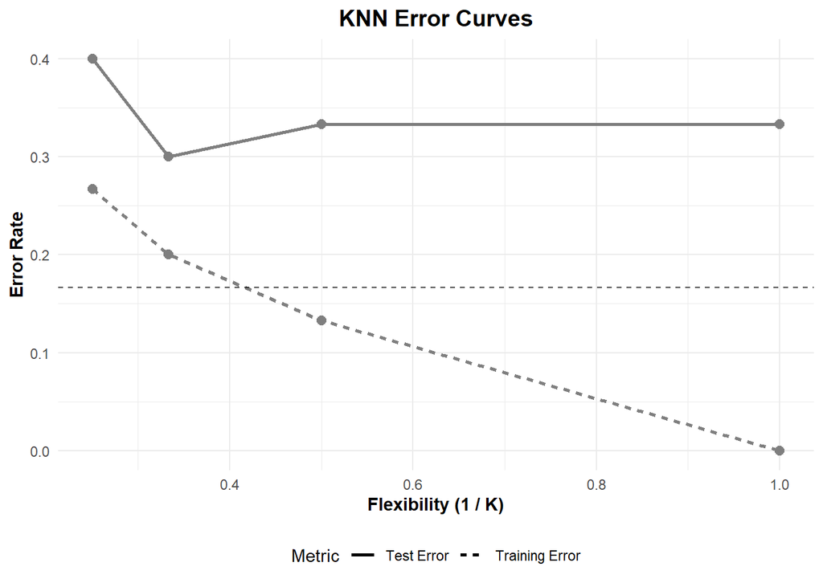

```r
library(ggplot2)

# 1. Preparing the dataframe with the model results.
dados_grafico <- data.frame(
  K = c(1, 2, 3, 4, 1, 2, 3, 4),
  Inv_K = c(1/1, 1/2, 1/3, 1/4, 1/1, 1/2, 1/3, 1/4),
  Erro = c(0.00, 0.133, 0.200, 0.267,     # Estimated Training Errors for n=30
           0.333, 0.333, 0.300, 0.400),   # Actual console test errors
  Tipo = c(rep("Training Error", 4), rep("Test Error", 4))
)

# 2. Creating the error curve graph
ggplot(dados_grafico, aes(x = Inv_K, y = Erro, color = Tipo, linetype = Tipo)) +
  geom_line(size = 1) +
  geom_point(size = 2.5) +
  # Horizontal dashed line showing the error of the Logistic Regression (16.67%)
  geom_hline(yintercept = 0.1667, linetype = "dashed", color = "black", alpha = 0.7) +
  scale_color_manual(values = c("Erro de Treino" = "#48bfa2", "Erro de Teste" = "#e68533")) +
  labs(
    x = "Flexibility (1 / K)",
    y = "Error Rate",
    title = "KNN Error Curves",
    color = "Metric",
    linetype = "Metric"
  ) +
  theme_minimal() +
  theme(
    plot.title = element_text(face = "bold", hjust = 0.5, size = 14),
    axis.title = element_text(face = "bold"),
    legend.position = "bottom"
  )
```

## 2.6 Simple Decision Tree

Moving on to tree-based models, we begin with a simple Decision Tree. It is a highly interpretable model that performs successive divisions in the space of predictor variables.

```r
library(tree)

# Adjusting the decision tree to the training data
tree.dados <- tree(TSH_class ~ SN + SD + SH + R + G + B + VARI + GLI + NGRDI,
                   data = dados,
                   subset = l_treino)

# Summary of the adjustment (Checking which variables were used in the nodes)
summary(tree.dados)
```

```
##
## Classification tree:
## tree(formula = TSH_class ~ SN + SD + SH + R + G + B + VARI +
##     GLI + NGRDI, data = dados, subset = l_treino)
## Variables actually used in tree construction:
## [1] "SN" "SD"
## Number of terminal nodes:  4
## Residual mean deviance:  0.2208 = 5.742 / 26
## Misclassification error rate: 0.03333 = 1 / 30
```

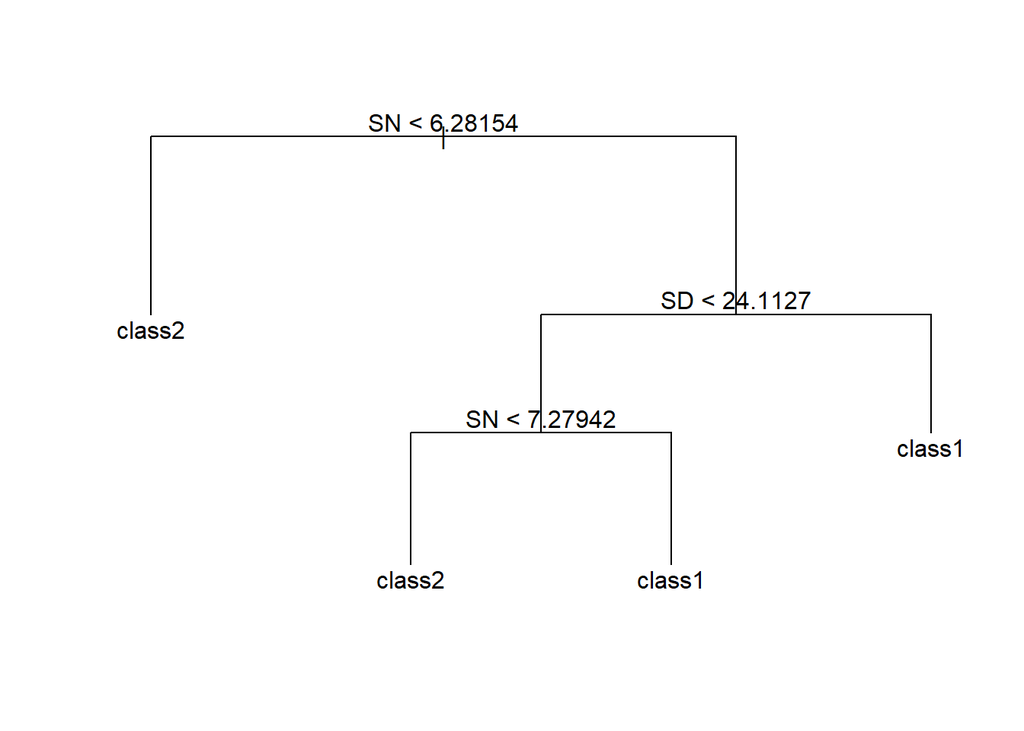

```r
# Visualizing the tree graphically
plot(tree.dados)
text(tree.dados, pretty = 0) # Add labels to nodes
```

```r
# Evaluating the Tree on the Test Set
tree.pred <- predict(tree.dados, dados[-l_treino, ], type = "class")
table(Predito = tree.pred, Real = dados$TSH_class[-l_treino])
```

```
##         Real
## Predito  class2 class1
##   class2     12      0
##   class1      5     13
```

```r
erro_test_tree <- mean(tree.pred != dados$TSH_class[-l_treino])
cat("Tree Error Rate in Testing:", erro_test_tree * 100, "%\n")
```

```
## Tree Error Rate in Testing: 16.66667 %
```

## 2.7 Random Forest

To see if we can improve the predictive capacity of the simple tree, we ajusted a Random Forest model. This method creates multiple trees using resampling of the training data (Bootstrap) and random selection of variables, reducing the variance of the model.

```r
library(randomForest)

set.seed(1)
# Adjusting the Random Forest with variable importance calculation (importance = TRUE)
rf.dados <- randomForest(TSH_class ~ SN + SD + SH + R + G + B + VARI + GLI + NGRDI,
                         data = dados,
                         subset = l_treino,
                         importance = TRUE)

# Checking the importance of each variable for the model.
importance(rf.dados)
```

```
##           class2     class1 MeanDecreaseAccuracy MeanDecreaseGini
## SN     6.3284845 12.9817068           11.9267561        3.3382772
## SD    -0.7775307  6.3895109            4.5271517        1.3623085
## SH     2.5803703  6.3784087            5.8247557        2.0901967
## R     -1.3159215 -1.1643016           -1.6092527        0.7474390
## G     -0.2174371  0.2923945            0.1815363        0.6919268
## B     -0.4108030  1.4431471            0.7437896        0.8480092
## VARI   0.9822646  6.0003033            4.5385992        2.2433188
## GLI    1.4521863  5.2629251            4.8205977        1.5144082
## NGRDI  3.4937452  1.9701797            3.1019575        1.4407823
```

```r
# Evaluating the Random Forest on the Test Set
rf.pred <- predict(rf.dados, newdata = dados[-l_treino, ])
table(Predito = rf.pred, Real = dados$TSH_class[-l_treino])
```

```
##         Real
## Predito  class2 class1
##   class2     11      3
##   class1      6     10
```

```r
erro_test_rf <- mean(rf.pred != dados$TSH_class[-l_treino])
cat("Error Rate of Random Forest in the Test:", erro_test_rf * 100, "%\n")
```

```
## Error Rate of Random Forest in the Test: 30 %
```

## 2.8 General Comparison of Methodologies

Finally, we compiled the error rates of all models evaluated in the test set to determine the best classification approach for this dataset.

```r
# Organizing the percentage results
erro_logistica <- erro_teste_l_glm * 100
erro_lda       <- erro_teste_lda * 100
erro_knn       <- taxa_test_K3 * 100     # Assuming K=3 as the best KNN
erro_arvore    <- erro_test_tree * 100
erro_rf        <- erro_test_rf * 100

# Building the comparison table
tabela <- data.frame(
  Methodology = c("Logistic Regression", "LDA (Linear)", "KNN (K=3)", "Simple Tree", "Random Forest"),

Boundary = c("Linear", "Linear", "Non-Linear", "Non-Linear", "Non-Linear"),
  Erro_Teste  = c(erro_logistica, erro_lda, erro_knn, erro_arvore, erro_rf)
)

# Sorting from smallest to largest error
tabela_ordenada <- tabela[order(tabela$Erro_Teste), ]
print(tabela_ordenada, row.names = FALSE)
```

```
##          Methodology   Boundary Erro_Teste
##  Logistic Regression     Linear   16.66667
##          Simple Tree Non-Linear   16.66667
##         LDA (Linear)     Linear   23.33333
##            KNN (K=3) Non-Linear   30.00000
##        Random Forest Non-Linear   30.00000
```

When evaluating the Logistic Regression model, we observed a lack of convergence in the algorithm and a zero training error rate. The reason for this phenomenon is directly related to the small size of the training sample compared to the large number of predictor variables, which allowed for perfect separation of classes by predictors, configuring a clear case of overfitting. Since Linear Discriminant Analysis (LDA) does not suffer from this instability in parameter estimation when classes are well separated, we chose to use it, among the linear models, for the evaluation in the third stage.

## 2.9 Evaluating the model improvement with the removal of variables

### 2.9.1 Lasso

From the correlation matrix, we see that the high linear correlation between several of the explanatory variables, namely: R, G, B, VARI, GLI, and NGRDI. With the goal of evaluating whether reducing the number of variables results in improved predictive performance of the chosen models, LDA and selection tree, we will use Lasso to choose which variables should be removed.

```r
library(glmnet)

all_predictors <- c("SN", "SD", "SH", "R", "G", "B", "VARI", "GLI", "NGRDI")
X_train_lasso  <- as.matrix(treino[, all_predictors])
y_train_lasso  <- treino$TSH_class

set.seed(1)
cv.out <- cv.glmnet(X_train_lasso, y_train_lasso, family = "binomial", alpha = 1)

lasso_coefs <- predict(cv.out, type = "coefficients", s = "lambda.1se")
print(lasso_coefs)
```

```
## 10 x 1 sparse Matrix of class "dgCMatrix"
##               lambda.1se
## (Intercept) -40.80593378
## SN            1.94705096
## SD            0.75978414
## SH            3.09579171
## R             .
## G             0.02574245
## B             .
## VARI          .
## GLI           .
## NGRDI         .
```

Note that the Lasso method excluded, with the exception of the variables SN, SD, SH, and G, the coefficients associated with the other variables. Thus, we will proceed with the adjustment of the LDA and selection tree models using these variables.

```r
selected_vars <- rownames(lasso_coefs)[which(lasso_coefs != 0)]
selected_vars <- selected_vars[selected_vars != "(Intercept)"]
print(selected_vars)
```

```
## [1] "SN" "SD" "SH" "G"
```

```r
#------------------
dados_reduzidos  <- dados[, c(selected_vars, "TSH_class")]
treino_reduzido <- dados_reduzidos[l_treino, ]
teste_reduzido   <- dados_reduzidos[-l_treino, ]
```

### 2.9.2 Linear Discriminant Analysis (LDA)

```r
lda.fit_reduzido <- lda(TSH_class ~ SN + SD + SH + G  , data = treino_reduzido)
print(lda.fit_reduzido)
```

```
## Call:
## lda(TSH_class ~ SN + SD + SH + G, data = treino_reduzido)
##
## Prior probabilities of groups:
##    class2    class1
## 0.4333333 0.5666667
##
## Group means:
##              SN       SD       SH        G
## class2 6.425940 23.70295 2.051285 86.06916
## class1 7.534298 24.68713 2.258829 85.39781
##
## Coefficients of linear discriminants:
##          LD1
## SN 1.6081691
## SD 0.7640286
## SH 3.9132623
## G  0.2013135
```

```r
#
# (*)TESTING ERROR RATE ---------------------------------------------------
lda.pred_reduzido <- predict(lda.fit_reduzido, newdata = teste_reduzido)
lda.class_reduzido <- lda.pred_reduzido$class


cat("\n--- LDA (REDUCED MODEL) TEST CONFUSION MATRIX ---\n")
```

```
##
## --- LDA (REDUCED MODEL) TEST CONFUSION MATRIX ---
```

```r
print(table(Predicted = lda.class_reduzido, True = teste_reduzido$TSH_class))
```

```
##          True
## Predicted class2 class1
##    class2     11      1
##    class1      6     12
```

```r
erro_test_lda_reduzido <- mean(lda.class_reduzido != teste_reduzido$TSH_class)
cat("LDA (Reduced Model) Test Error Rate:", erro_test_lda_reduzido * 100, "%\n")
```

```
## LDA (Reduced Model) Test Error Rate: 23.33333 %
```

TRAINING ERROR RATE

```r
lda.pred_treino_reduzido <- predict(lda.fit_reduzido, newdata = treino_reduzido)
lda.class_treino_reduzido <- lda.pred_treino_reduzido$class
cat("\n--- LDA (REDUCED MODEL) TRAINING CONFUSION MATRIX ---\n")
```

```
##
## --- LDA (REDUCED MODEL) TRAINING CONFUSION MATRIX ---
```

```r
print(table(Predicted = lda.class_treino_reduzido, Real = treino_reduzido$TSH_class))
```

```
##          Real
## Predicted class2 class1
##    class2     12      0
##    class1      1     17
```

```r
erro_treino_lda_reduzido <- mean(lda.class_treino_reduzido != treino_reduzido$TSH_class)
cat("LDA (Reduced Model) Training Error Rate:", erro_treino_lda_reduzido * 100, "%\n")
```

```
## LDA (Reduced Model) Training Error Rate: 3.333333 %
```

```r
#(*) FULL DATASET ERROR RATE --------------------------------------------------
# Refitting the LDA model across the entire reduced dataset
lda.fit_total_reduzido <- lda(TSH_class ~ SN + SD + SH + G,
                              data = dados_reduzidos)

lda.pred_total_reduzido <- predict(lda.fit_total_reduzido, newdata = dados_reduzidos)
lda.class_total_reduzido <- lda.pred_total_reduzido$class

# Full Dataset Confusion Matrix
cat("\n--- LDA (REDUCED MODEL) FULL DATASET CONFUSION MATRIX ---\n")
```

```
##
## --- LDA (REDUCED MODEL) FULL DATASET CONFUSION MATRIX ---
```

```r
print(table(Predicted = lda.class_total_reduzido, Real = dados_reduzidos$TSH_class))
```

```
##          Real
## Predicted class2 class1
##    class2     26      2
##    class1      4     28
```

```r
# Full Dataset Error Calculation
erro_total_lda_reduzido <- mean(lda.class_total_reduzido != dados_reduzidos$TSH_class)
cat("LDA (Reduced Model) Full Dataset Error Rate:", erro_total_lda_reduzido * 100, "%\n")
```

```
## LDA (Reduced Model) Full Dataset Error Rate: 10 %
```

### 2.9.3 Simple Decision Tree

```r
library(tree)
tree.dados_redu <- tree(TSH_class ~ SN + SD + SH + G,
                        data = dados_reduzidos,
                        subset = l_treino)

summary(tree.dados_redu)
```

```
##
## Classification tree:
## tree(formula = TSH_class ~ SN + SD + SH + G, data = dados_reduzidos,
##     subset = l_treino)
## Variables actually used in tree construction:
## [1] "SN" "SD"
## Number of terminal nodes:  4
## Residual mean deviance:  0.2208 = 5.742 / 26
## Misclassification error rate: 0.03333 = 1 / 30
```

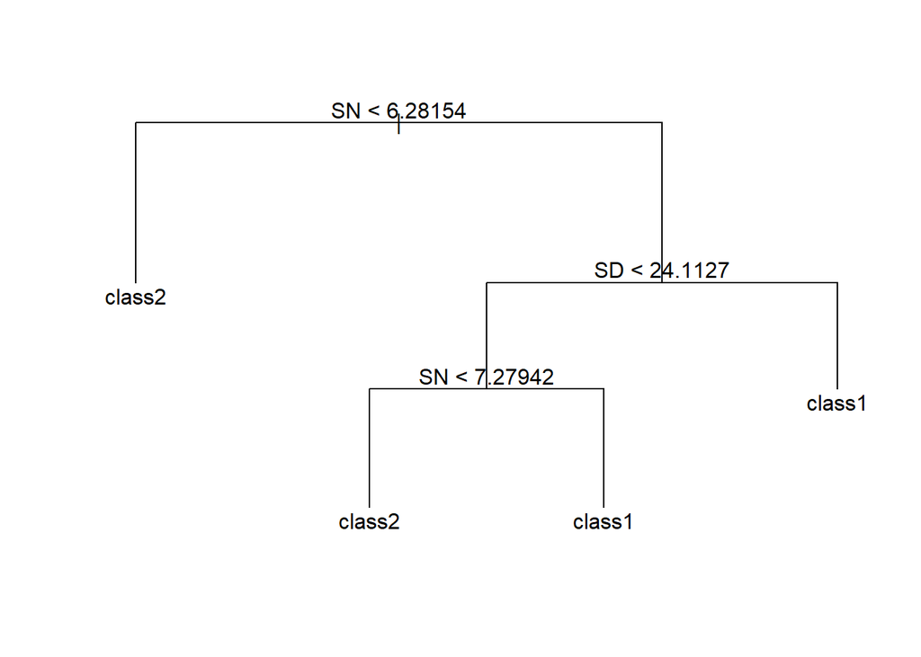

```r
#
# Visualizing the Tree Structure
plot(tree.dados_redu)
text(tree.dados_redu, pretty = 0) # Displays node splits with actual threshold values
```

```r
# TESTING ERROR RATE ---------------
# Predicting classes on the independent test subset
tree.pred_redu <- predict(tree.dados_redu, newdata = dados_reduzidos[-l_treino, ], type = "class")
# Testing Confusion Matrix
cat("\n--- DECISION TREE TESTING CONFUSION MATRIX---\n")
```

```
##
## --- DECISION TREE TESTING CONFUSION MATRIX---
```

```r
print(table(Predicted = tree.pred_redu, True = dados_reduzidos$TSH_class[-l_treino]))
```

```
##          True
## Predicted class2 class1
##    class2     12      0
##    class1      5     13
```

```r
#Testing Error Calculation
erro_test_tree_redu <- mean(tree.pred != dados_reduzidos$TSH_class[-l_treino])
cat("Decision Tree Testing Error Rate:", erro_test_tree_redu * 100, "%\n")
```

```
## Decision Tree Testing Error Rate: 16.66667 %
```

TRAINF ERROR RATE

```r
#predicting classes on the train data set
tree.pred_train_redu <- predict(tree.dados_redu, newdata = dados_reduzidos[l_treino, ], type = "class")
# Traing Confusion Matrix
cat("\n--- DECISION TREE TRAING CONFUSION MATRIX ---\n")
```

```
##
## --- DECISION TREE TRAING CONFUSION MATRIX ---
```

```r
print(table(Predicted = tree.pred_train_redu, True = dados_reduzidos$TSH_class[l_treino]))
```

```
##          True
## Predicted class2 class1
##    class2     12      0
##    class1      1     17
```

```r
# Testing Error Calculation
erro_train_tree_redu <- mean(tree.pred_train_redu != dados_reduzidos$TSH_class[l_treino])
cat("Decision Tree Traing Error Rate:", erro_train_tree_redu * 100, "%\n")
```

```
## Decision Tree Traing Error Rate: 3.333333 %
```

FULL DATASET ERROR RATE

```r
#Refitting the decision tree across the entire dataset
tree.dados_total_redu <- tree(TSH_class ~ SN + SD + SH + G,
                              data = dados_reduzidos)

#Predicting classes.
tree.pred_total_redu <- predict(tree.dados_total_redu, newdata = dados_reduzidos, type = "class")

#Confusion Matrix
cat("\n--- DECISION TREE FULL DATASET CONFUSION MATRIX ---\n")
```

```
##
## --- DECISION TREE FULL DATASET CONFUSION MATRIX ---
```

```r
print(table(Predicted = tree.pred_total_redu, True = dados_reduzidos$TSH_class))
```

```
##          True
## Predicted class2 class1
##    class2     30      2
##    class1      0     28
```

```r
#Error rate
erro_total_tree_redu <- mean(tree.pred_total_redu != dados_reduzidos$TSH_class)
cat("Decision Tree Full Dataset Error Rate:", erro_total_tree_redu * 100, "%\n")
```

```
## Decision Tree Full Dataset Error Rate: 3.333333 %
```

### 2.9.4 Table for comparing the models

```r
final_table <- data.frame(
  Approach = c("Full Model ",
               "Lasso Reduced Model "),

  LDA_Test_Error = c(erro_teste_lda, erro_test_lda_reduzido),

  Decision_Tree_Test_Error = c(erro_test_tree, erro_test_tree_redu)
)

#

print(final_table, row.names = FALSE)
```

```
##              Approach LDA_Test_Error Decision_Tree_Test_Error
##           Full Model       0.2333333                0.1666667
##  Lasso Reduced Model       0.2333333                0.1666667
```

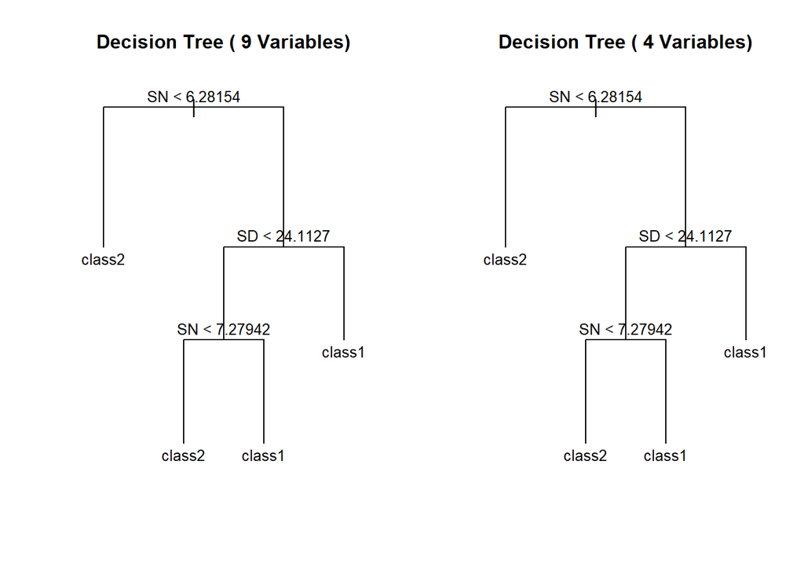

```r
# arvores
par(mfrow = c(1, 2))
plot(tree.dados)
text(tree.dados, pretty = 0, cex = 0.8)
title(main = "Decision Tree ( 9 Variables)", line = 2, cex.main = 1)
#
plot(tree.dados_redu)
text(tree.dados_redu, pretty = 0, cex = 0.8)
title(main = "Decision Tree ( 4 Variables)", line = 2, cex.main = 1)
```

```r
par(mfrow = c(1, 1))
```

We observed that the test error rates remained the same when evaluating the LDA model and the decision tree with a reduced number of predictors. This fact highlights the redundancy of the removed variables, since their exclusion did not affect the predictive capacity and the fit of the models. In the case of LDA, the removal of these variables was fundamental, as they did not contribute new information to the classification and also harmed the accuracy of the coefficient estimates, inflating their associated variances.

With regard to the decision tree, it was expected that the structure and estimates would remain unchanged, since the recursive binary splitting mechanics of the algorithm naturally make it immune to the problem of multicollinearity.

# 3 Regression Problem

## 3.1 Regression Models

In the first step, we converted the TSH variable to continuous, as it was used as a factor in the classification models part, and then we divided the data into a 50% training and 50% test validation set.

```r
dados_modelagem <- dados %>%
  dplyr::select(-Family) %>%
  dplyr::mutate(TSH = as.numeric(as.character(TSH)))

# Preparation and Division (50/50)

# Removing the Family variable
dados_modelagem <- dados %>% dplyr::select(-Family)

#Reproducible division of data
set.seed(123)
indices_treino <- sample(1:nrow(dados_modelagem), size = 0.5 * nrow(dados_modelagem))

treino <- dados_modelagem[indices_treino, ]
teste  <- dados_modelagem[-indices_treino, ]
```

We use a Linear model with all variables

```r
modelo_completo <- lm(TSH ~ . - Family, data = dados)
summary(modelo_completo)
```

```
##
## Call:
## lm(formula = TSH ~ . - Family, data = dados)
##
## Residuals:
##      Min       1Q   Median       3Q      Max
## -11.1587  -4.2639  -0.4446   4.0890  14.3656
##
## Coefficients:
##                   Estimate Std. Error t value Pr(>|t|)
## (Intercept)      -203.8704    61.1177  -3.336 0.001629 **
## SN                 11.8754     1.1838  10.032 1.81e-13 ***
## SD                  5.8444     0.7853   7.442 1.37e-09 ***
## SH                 26.2396     5.8202   4.508 4.08e-05 ***
## R                   1.1356     6.2154   0.183 0.855780
## G                 -14.8871     9.3962  -1.584 0.119541
## B                  14.2539    14.6473   0.973 0.335261
## VARI             1469.9673  2338.0273   0.629 0.532452
## GLI              4200.4752  4841.1128   0.868 0.389806
## NGRDI           -4565.6409  7653.3290  -0.597 0.553550
## TSH_classclass1     9.6429     2.5682   3.755 0.000461 ***
## ---
## Signif. codes:  0 '***' 0.001 '**' 0.01 '*' 0.05 '.' 0.1 ' ' 1
##
## Residual standard error: 6.198 on 49 degrees of freedom
## Multiple R-squared:  0.937,  Adjusted R-squared:  0.9242
## F-statistic: 72.94 on 10 and 49 DF,  p-value: < 2.2e-16
```

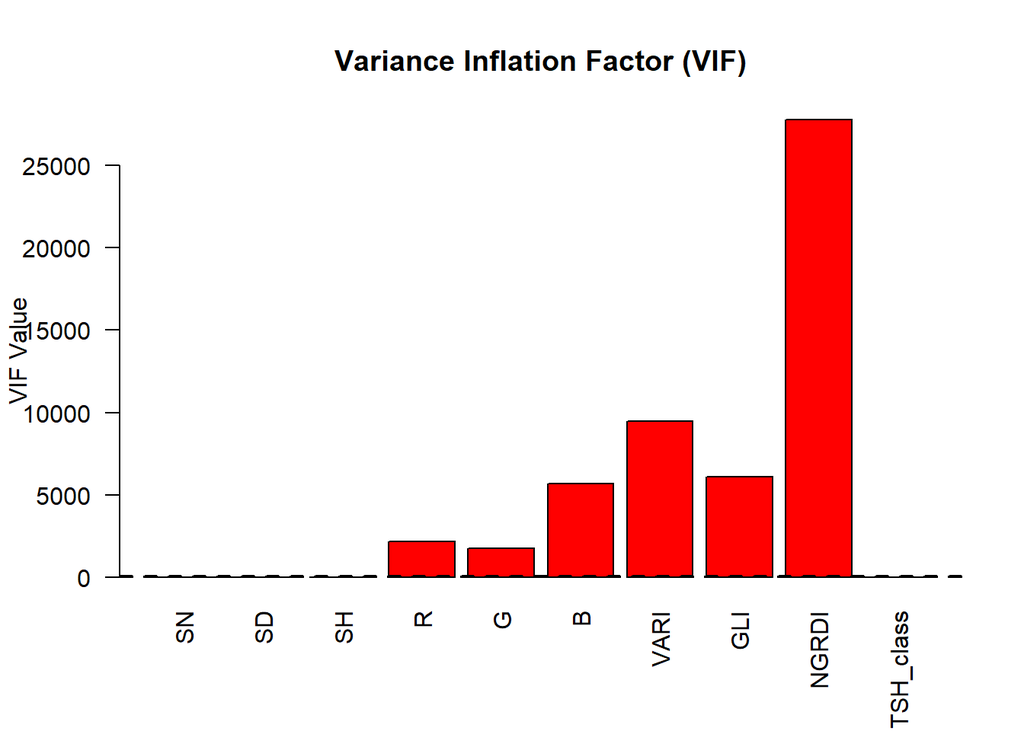

```r
# Calculation and plotting of the VIF
valores_vif <- vif(modelo_completo)

barplot(valores_vif,
        main = "Variance Inflation Factor (VIF)",
        col = ifelse(valores_vif > 10, "red", "steelblue"),
        las = 2,
        ylab = "VIF Value")
abline(h = 10, col = "black", lty = 2, lwd = 2)
```

Due to the multicollinearity problem, initially indicated by the correlation matrix and confirmed by the high VIF values, we performed a variable selection process in the model in order to remove the multicollinearity and obtain a more parsimonious model. For this, a stepwise selection process was carried out.

```r
#  Selection Stepwise Forward
mod_step_vs <- step(lm(TSH ~ 1, data = treino),
                    scope = formula(lm(TSH ~ ., data = treino)),
                    direction = "both", trace = 0)
summary(mod_step_vs)
```

```
##
## Call:
## lm(formula = TSH ~ TSH_class + SH + SN + SD, data = treino)
##
## Residuals:
##      Min       1Q   Median       3Q      Max
## -13.7498  -4.5886   0.7549   4.4035  13.6836
##
## Coefficients:
##                 Estimate Std. Error t value Pr(>|t|)
## (Intercept)     -182.336     28.869  -6.316 1.31e-06 ***
## TSH_classclass1    7.341      4.052   1.812 0.082070 .
## SH                35.568      9.692   3.670 0.001150 **
## SN                12.617      1.580   7.987 2.42e-08 ***
## SD                 5.467      1.297   4.214 0.000285 ***
## ---
## Signif. codes:  0 '***' 0.001 '**' 0.01 '*' 0.05 '.' 0.1 ' ' 1
##
## Residual standard error: 7.4 on 25 degrees of freedom
## Multiple R-squared:  0.9296, Adjusted R-squared:  0.9183
## F-statistic: 82.52 on 4 and 25 DF,  p-value: 4.965e-14
```

## 3.2 Principal Component Extraction (PCA)

As an alternative to the multicollinearity of the linear model, dimensionality reduction using principal components emerges as an excellent option, since the components are orthogonal to each other and do not exhibit autocorrelation.

Therefore, we chose to test this approach, as it does not require the exclusion of variables in this case.

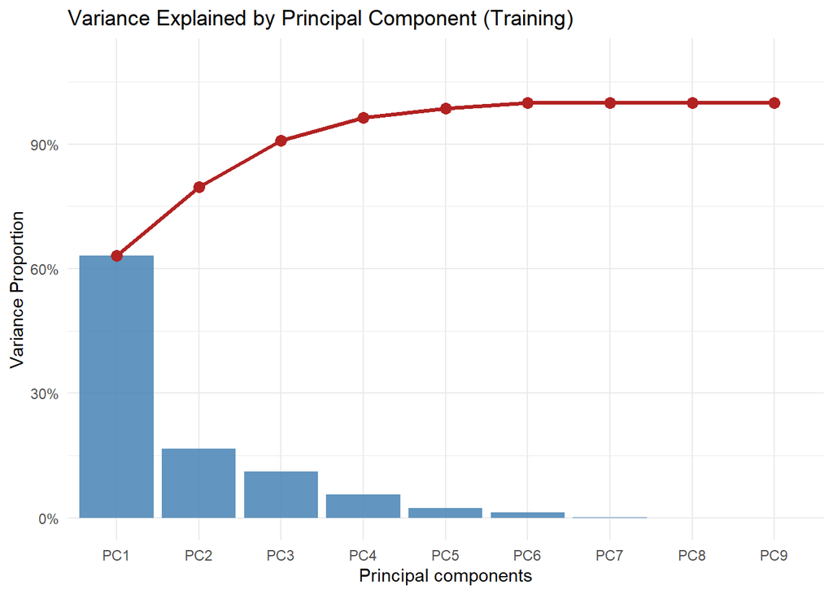

```r
# --- Dimensionality Reduction (PCA) and Visualization ---
library(ggplot2)
library(factoextra)

# 1. Extracting PCA only in Training
dados_pca_treino_covariadas <- treino %>%
  dplyr::select(-TSH) %>%
  dplyr::select(where(is.numeric)) # Safety lock for numeric variables

pca_treino <- prcomp(dados_pca_treino_covariadas, center = TRUE, scale. = TRUE)

# 2. Preparing the data for the Scree Plot
var_explicada <- pca_treino$sdev^2
prop_var <- var_explicada / sum(var_explicada)
var_acumulada <- cumsum(prop_var)

df_pca_var <- data.frame(
  Componente = factor(paste0("PC", 1:length(prop_var)), levels = paste0("PC", 1:length(prop_var))),
  Proporcao = prop_var,
  Acumulada = var_acumulada
)

# 3. Variance Plot (Scree Plot)
ggplot(df_pca_var, aes(x = Componente)) +
  geom_bar(aes(y = Proporcao), stat = "identity", fill = "steelblue", alpha = 0.85) +
  geom_line(aes(y = Acumulada, group = 1), color = "firebrick", linewidth = 1.2) +
  geom_point(aes(y = Acumulada), color = "firebrick", size = 3) +
  scale_y_continuous(labels = scales::percent_format(), limits = c(0, 1.1)) +
  theme_minimal() +
  labs(title = "Variance Explained by Principal Component (Training)",
       x = "Principal components", y = "Variance Proportion")
```

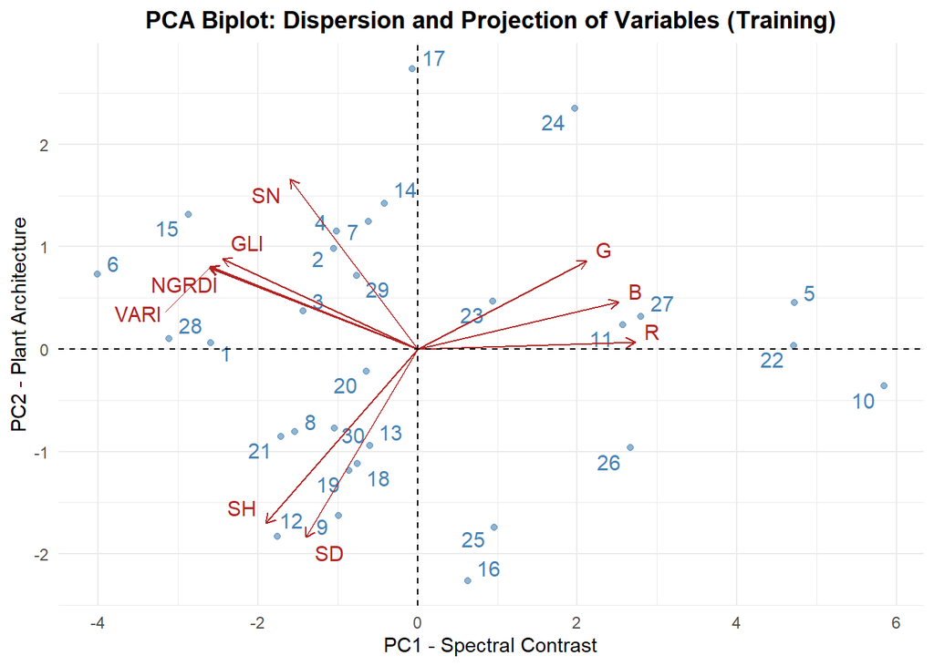

```r
# 4. Biplot Graph
fviz_pca_biplot(pca_treino,
                repel = TRUE,                               col.var = "firebrick",
                col.ind = "steelblue",
                alpha.ind = 0.6,
                title = "PCA Biplot: Dispersion and Projection of Variables (Training)",
                xlab = "PC1 - Spectral Contrast",
                ylab = "PC2 - Plant Architecture") +
  theme_minimal() +
  theme(plot.title = element_text(face = "bold", hjust = 0.5))
```

```r
# 5. Projecting the test data into the training PCA space for future use
dados_pca_teste_covariadas <- teste %>%
  dplyr::select(-TSH) %>%
  dplyr::select(where(is.numeric))

pred_pca_teste <- as.data.frame(predict(pca_treino, newdata = dados_pca_teste_covariadas)[, 1:4])
```

It was decided to retain the first four components, which account for most of the variability of the original predictors.

## 3.3 Adjustment of the principal component regression model

```r
# # Creating the PCR database for training (using the first 3 PCs)
dados_pcr_treino <- cbind(treino %>% dplyr::select(TSH), pca_treino$x[, 1:4])

# Complete PCR Model (3 components)
modelo_pcr_completo <- lm(TSH ~ PC1 + PC2 + PC3 + PC4, data = dados_pcr_treino)
summary(modelo_pcr_completo)
```

```
##
## Call:
## lm(formula = TSH ~ PC1 + PC2 + PC3 + PC4, data = dados_pcr_treino)
##
## Residuals:
##      Min       1Q   Median       3Q      Max
## -17.4538  -4.7851   0.1795   4.6519  13.8477
##
## Coefficients:
##             Estimate Std. Error t value Pr(>|t|)
## (Intercept) 116.8254     1.4147  82.579  < 2e-16 ***
## PC1          -8.5877     0.6035 -14.230 1.71e-13 ***
## PC2          -1.7140     1.1787  -1.454    0.158
## PC3          -6.6838     1.4402  -4.641 9.45e-05 ***
## PC4         -17.3368     2.0336  -8.525 7.23e-09 ***
## ---
## Signif. codes:  0 '***' 0.001 '**' 0.01 '*' 0.05 '.' 0.1 ' ' 1
##
## Residual standard error: 7.749 on 25 degrees of freedom
## Multiple R-squared:  0.9228, Adjusted R-squared:  0.9104
## F-statistic:  74.7 on 4 and 25 DF,  p-value: 1.562e-13
```

```r
# Stepwise refinement in the PCR model (Direction: Both)
modelo_pcr_refinado <- step(modelo_pcr_completo, direction = "both", trace = 0)
summary(modelo_pcr_refinado)
```

```
##
## Call:
## lm(formula = TSH ~ PC1 + PC2 + PC3 + PC4, data = dados_pcr_treino)
##
## Residuals:
##      Min       1Q   Median       3Q      Max
## -17.4538  -4.7851   0.1795   4.6519  13.8477
##
## Coefficients:
##             Estimate Std. Error t value Pr(>|t|)
## (Intercept) 116.8254     1.4147  82.579  < 2e-16 ***
## PC1          -8.5877     0.6035 -14.230 1.71e-13 ***
## PC2          -1.7140     1.1787  -1.454    0.158
## PC3          -6.6838     1.4402  -4.641 9.45e-05 ***
## PC4         -17.3368     2.0336  -8.525 7.23e-09 ***
## ---
## Signif. codes:  0 '***' 0.001 '**' 0.01 '*' 0.05 '.' 0.1 ' ' 1
##
## Residual standard error: 7.749 on 25 degrees of freedom
## Multiple R-squared:  0.9228, Adjusted R-squared:  0.9104
## F-statistic:  74.7 on 4 and 25 DF,  p-value: 1.562e-13
```

Even though it wasn’t significant, after performing the variable selection process, the PC2 component remained in the model, so we chose to keep it.

## 3.4 Partial Least Squares (PLS) Model

```r
library(pls)

# Ensuring that the PLS database in training contains only numerical variables.
dados_pls_treino <- treino %>% dplyr::select(where(is.numeric))

# 1. Initial PLS adjustment with Cross-Validation (CV) on the Training set
set.seed(1)
pls.fit <- plsr(TSH ~ ., data = dados_pls_treino, scale = TRUE, validation = "CV")

# Displays the model summary (cumulative R² and error per component)
summary(pls.fit)
```

```
## Data:    X dimension: 30 9
##  Y dimension: 30 1
## Fit method: kernelpls
## Number of components considered: 9
##
## VALIDATION: RMSEP
## Cross-validated using 10 random segments.
##        (Intercept)  1 comps  2 comps  3 comps  4 comps  5 comps  6 comps
## CV           26.34    15.39    10.56    8.432    8.659    9.067    8.974
## adjCV        26.34    15.34    10.28    8.344    8.564    8.942    8.874
##        7 comps  8 comps  9 comps
## CV       8.101    8.411    9.666
## adjCV    7.989    8.267    9.441
##
## TRAINING: % variance explained
##      1 comps  2 comps  3 comps  4 comps  5 comps  6 comps  7 comps  8 comps
## X      62.80    72.08    82.78    96.09    98.39    99.98   100.00   100.00
## TSH    68.92    89.83    92.59    92.84    93.00    93.05    94.82    95.06
##      9 comps
## X     100.00
## TSH    95.14
```

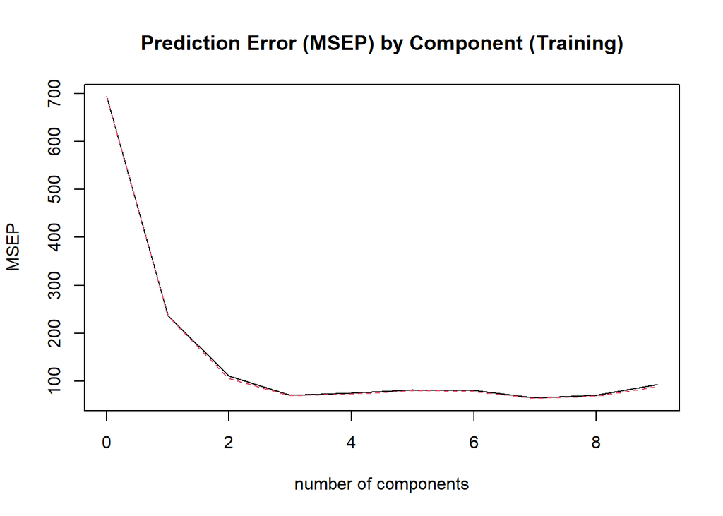

```r
# Plot the MSEP (Mean Squared Error of Prediction) to identify the minimum point.
validationplot(pls.fit, val.type = "MSEP", main = "Prediction Error (MSEP) by Component (Training)")
```

```r
# 2. Final Model Adjustment with the Ideal Number of Components (3 components)
# We will use the name mod_pls_vs to connect with the subsequent prediction block.
mod_pls_vs <- plsr(TSH ~ ., data = dados_pls_treino, scale = TRUE, ncomp = 3)

summary(mod_pls_vs)
```

```
## Data:    X dimension: 30 9
##  Y dimension: 30 1
## Fit method: kernelpls
## Number of components considered: 3
## TRAINING: % variance explained
##      1 comps  2 comps  3 comps
## X      62.80    72.08    82.78
## TSH    68.92    89.83    92.59
```

The final Partial Least Squares (PLS) fitted model with 3 components demonstrated excellent predictive capacity and high efficiency in dimensionality reduction. The three constructed latent variables were able to synthesize 82.78% of the variability contained in the original set of predictors ($X$), eliminating the redundancies caused by the severe multicollinearity observed previously.

```r
# 3. Extract the loadings of the predictor variables for the 3 components.
cargas_pls <- loadings(mod_pls_vs)[, 1:3]
print(cargas_pls)
```

```
##           Comp 1      Comp 2        Comp 3
## SN     0.2451264  0.16172842  0.8336210170
## SD     0.2325949  0.64192788 -0.5824545807
## SH     0.3029762  0.47753399 -0.2653559780
## R     -0.4026623  0.33803758 -0.0445310720
## G     -0.3074242  0.44389433 -0.0570787146
## B     -0.3696373  0.38348109  0.0116613168
## VARI   0.3904206 -0.11706831 -0.0002752092
## GLI    0.3676526 -0.07232953 -0.0564609700
## NGRDI  0.3916718 -0.12170056  0.0031341860
```

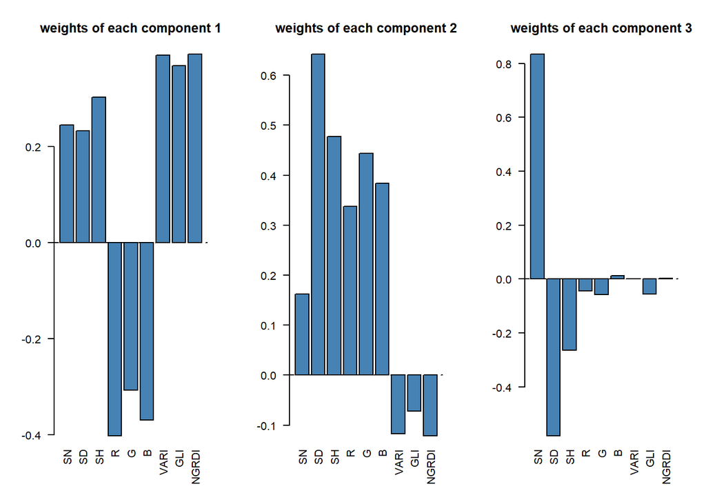

```r
# Bar chart to visualize the weights of each component
par(mfrow = c(1, 3))
for(i in 1:3) {
  barplot(cargas_pls[, i],
          main = paste("weights of each component", i),
          col = "steelblue", las = 2)
  abline(h = 0, lty = 2)
}
```

```r
# Reset the graphic layout so it doesn't affect future plots in the document.
par(mfrow = c(1, 1))
```

The interpretation of the loadings of the latent variables brought very interesting nuances to the structure of the PLS model. Component 1 was characterized by the strong contrast between the positive spectral indices (NGRDI = 0.392; VARI = 0.390) and the negative visible bands (R = -0.403; B = -0.370), also associated with plant height growth (SH = 0.303). Component 2, responsible for the large leap in explaining the variance of TSH, assumed the role of the axis of structural robustness. In it, the biometric variables of stem diameter (SD = 0.642) and height (SH = 0.478) took center stage, demonstrating that the physical support structure is determinant for the final yield. Finally, Component 3 revealed the PLS’s ability to model the morphological compensation architecture of the crop: it exhibits a very strong positive weight for the number of stalks (SN = 0.834) counteracting the negative weights of diameter (SD = -0.582) and height (SH = -0.265), perfectly capturing the balance between many thin stalks versus few thick stalks in the final productivity adjustment.